# Capstone: IGN Editor’s Choice Award

## Introduction

- Videogames are a multi-billion industry that compromise of numerous gaming studios and publishers, with thousands of game developers
- Usually success of gaming studios measured in:
  - Rating of their games
  - Awards received
- Resulting in:
  - More consumers
  - More sales and profits
  - Receive funding and partnership with major publishers for future projects and development

## Editor's Choice Award

- The Editor’s Choice award from the videogame review website IGN
- Obtaining such awards give an idea for developers on what type of projects they should pursue to earn this achievement for their future games

**Purpose**

- What variables of a video game will allow us to predict if the game will win an Editor's Choice award through a logistic regression model

## Dataset

- Dataset used for this project is from Kaggle, 20 Years of Games by Eric Grinstein (https://www.kaggle.com/egrinstein/20-years-of-games)
- Includes 18,625 video games reviews from IGN that range from games released from 1996-2016:
  - 3,517 winners of the Editor's Choice award (18.88%)
  - 15,108 were non-winners (81.12%)

## Predictor Variables (Original)

- **X1**
- **Score_phrase**
- **Title**
- **Url**
- **Platform**
- **Score**
- **Genre**
- **Editor_choice**
- **Release_year**
- **Release_month**
- **Release_day**

## Predictor Variables (Introduced)

- **Tot_Plat**: total number of platforms the videogame is released on
- **Word_count**: total number of words in the videogame title
- **Char_count**: total number of characters in the videogame title
- **Title_start**: the starting letter of the videogame title (#, A-Z)
- **Number**: videogame contains a number in the title
- **Franchise**: videogame contains a certain franchise name in the title
- **Top_genre**: videogame's genre is a top 10 genre

## Exploratory Data Analysis (EDA)

- From the original dataset we will focus on a 5 year period (2012 to 2016)
- New dataset consisted of 1,612 games:
  - 290 winners of the Editor’s Choice Award (17.99%)
  - 1322 non-winners (82.01%)

## EDA Plot Analysis: Platform

Nintendo DS and SteamOS high proportion winners, while Arcade and Web Games some of the non-winners

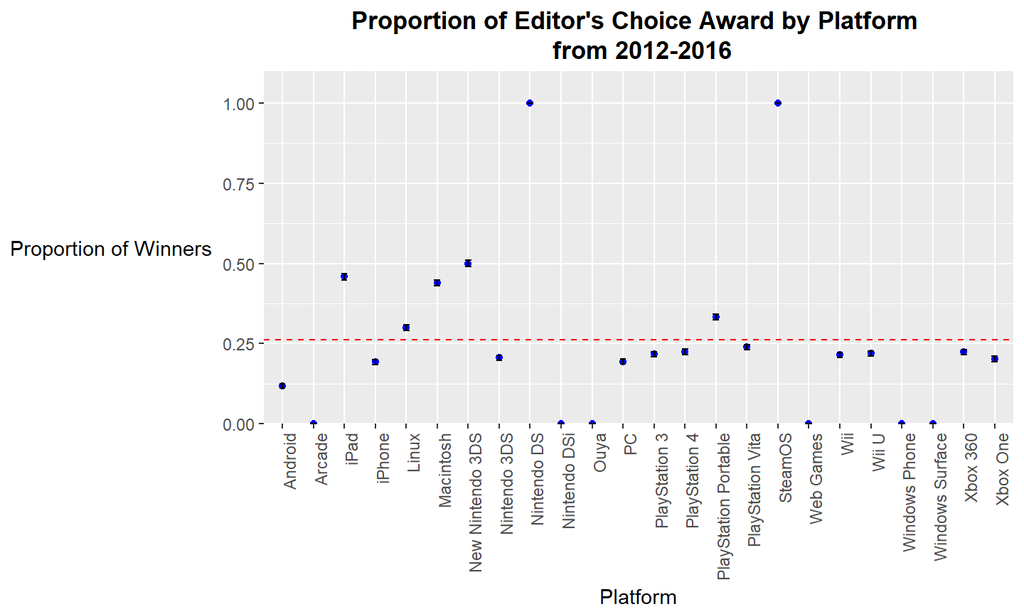

## EDA Plot Analysis: Top Genre

Racing, Platformer and Role Playing Games (RPG) were top 3 proportion of winners, while Sports had the lowest

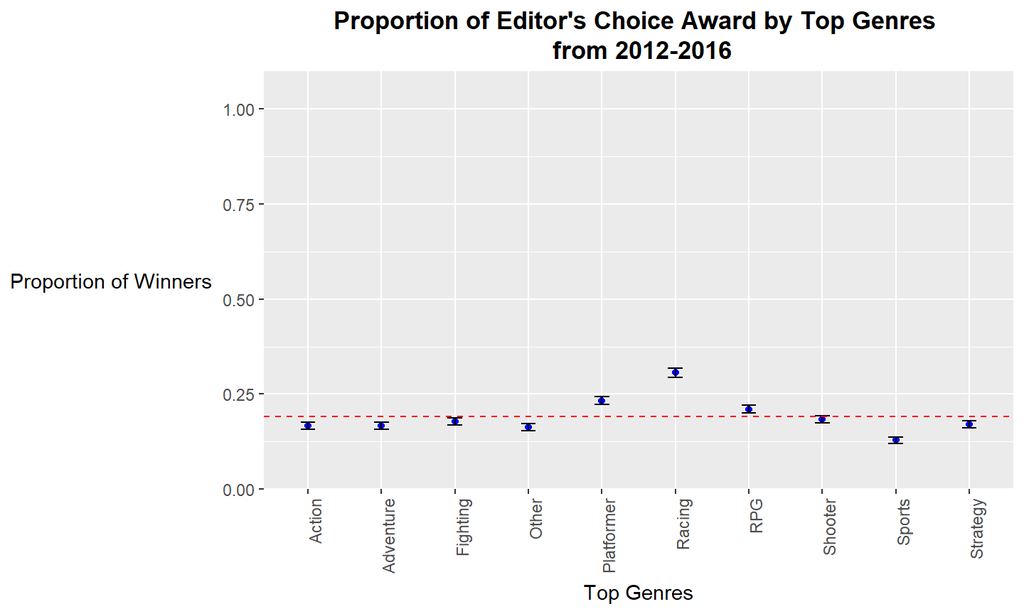

## EDA Plot Analysis: Franchise

Warcraft, Forza and Uncharted were top 3 proportion of winners, while Resident Evil, FIFA, and Star Wars had the lowest

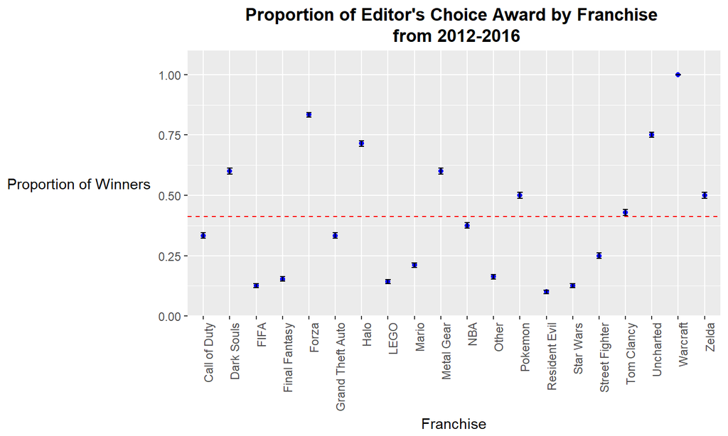

## EDA Plot Analysis: Release Month

September had the highest proportion of award winners and the December had the lowest

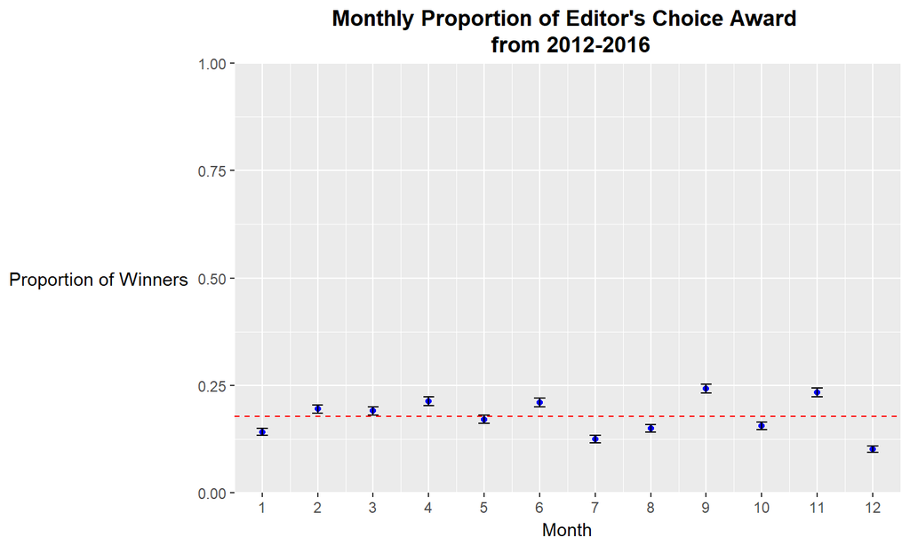

## EDA Plot Analysis: Character Count

The spread was slightly larger in the award winners compared to non-winners, but suggest it was best to limit the count within the winner's IQR, around the median of 18 characters

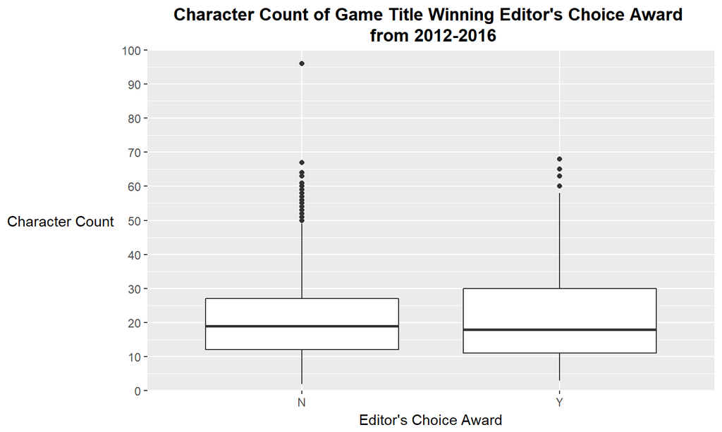

## **Selecting Predictor Variables:**

- The Akaike Information Criterion (AIC) was used to measure the relative quality of the model, where the minimum AIC would be the most optimal. Predictor variables were added or removed in order to minimize the AIC to determine the chosen final model

| Model | AIC |
| --- | --- |
| Original | 1189.2 |
| New | 1126.2 |
| Final | 1125.2 |

## **Confusion Matrix Statistics:**

- Sensitivity (True Positive Rate)
- Specificity (True Negative Rate)
- Accuracy
- Error Rate

| Model | Sensitivity | Specificity | Accuracy | Error Rate |
| --- | --- | --- | --- | --- |
| Original | 0.0412 | 0.998 | 0.826 | 0.173 |
| New | 0.178 | 0.984 | 0.839 | 0.160 |
| Final | 0.161 | 0.989 | 0.840 | 0.160 |

## **Receiver Operator Character Curve:**

- Pick threshold to maximize sensitivity and specificity for the logistic regression model (t = 0.2)
- Curve does better than random guessing of award winners

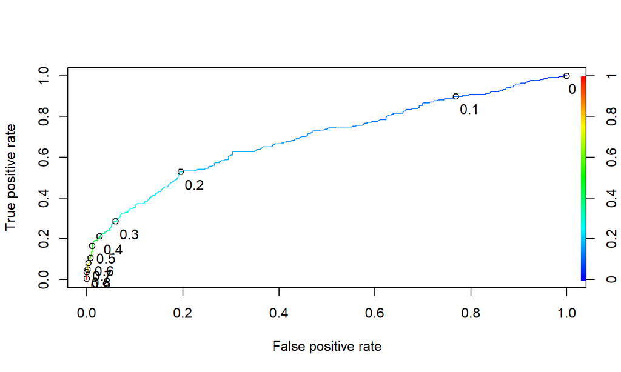

## **AUC:**

- The area under the ROC curve (AUC) was then used to measure the quality of the model where given a random positive and negative proportion of the time, the model is able to guess correctly when a video game wins the Editor's Choice Award. A minimum baseline AUC of 0.50, representing random guessing, and AUC of 1, representing perfect prediction, were used.

| Model | AUC |
| --- | --- |
| Original | 0.656 |
| New | 0.756 |
| Final | 0.695 |

## **Threshold:**

[output not shown]

## **Recommendations:**

From the results of this optimum final model, we can make some good recommendations for videogame developers to potentially increase their chance to win the Editor's Choice award.

## **Platforms:**

- Portable gaming systems: Nintendo 3DS, PlayStation Portable, iPad, iPhone, PlayStation Vita
- In the last 5 years (2012-2016), this new trend of "gaming on the go" has been heavily popularized in the gaming industry market as seen with an influx of mobile and smartphone application games over traditional in-home systems
- In-home consoles: Macintosh and Wii U
- In-home consoles still an option due to a strong established gaming markets

## **Franchise:**

- Dark Souls
- Forza
- Halo
- Zelda
- Developers and publishers that own the rights to these franchises should be motivated to continue on these projects
- For new videogame developers or developers from different game studios, these four franchises can provide a blueprint of notable styles, features, and game engines that they can incorporate into their own games (within the scope of not infringing copyright or proprietary laws)

## **Number:**

- Videogames that had a number in their title either through a numerical or yearly-based format were more likely to win the Editor's Choice award
- This allows one way for developers to grow their games with new iterations and establish them into potential franchise games

## **Character Count:**

- Limit the range of the game title's character count to 11 to 30 characters (from IQR range in EDA plot) for the best chance to win the Editor's Choice award
- Having too much characters (potentially words) in the title may confuse consumers and reviewers and cause them not to fully understand the game

## Further Research

- Upgraded Dataset:
  - A more updated game list of Oculus Rift, PlayStation VR and other VR platforms
  - Variables like the publishers, gaming studios, and game engines
  - Videogame units sold and/or their sale numbers
- Follow-Up:
  - VR platforms
  - Discontinued Franchises and Platforms
  - Nintendo Switch, Zelda

## Thank You

- Springboard
- Karen Lowe (Mentor)
- Game Developers and Studios